# Reproducable Research - Course Project 1

## Project 1 - Reproducable Research

Introduction - This assignment is part of the course project for the Reproducable Research course. For the purpose of this assignment Sample data is made available from an Activity Moitoring Device.

### Dataset Details:

Dataset: Activity monitoring data [52K] The variables included in this dataset are: steps: Number of steps taking in a 5-minute interval (missing values are coded as NA) date: The date on which the measurement was taken in YYYY-MM-DD format interval: Identifier for the 5-minute interval in which measurement was taken The dataset is stored in a comma-separated-value (CSV) file and there are a total of 17,568 observations in this dataset.

#### 1. Code for reading in the dataset and/or processing the data

```r
  library(ggplot2)
  ds <- read.csv("E:\\DS\\5 - Reproducable Research\\activity.csv", header=TRUE,sep=",")
  ds$date <- as.Date(ds$date)
```

#### 2. Histogram of the total number of steps taken each day

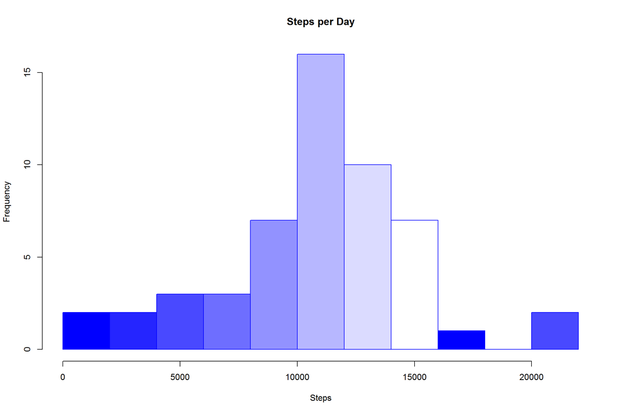

```r
ds_day <- aggregate(data=ds, steps~date, sum,na.rm = TRUE)
hist(ds_day$steps,  breaks = 10, col=colorRampPalette(c(rgb(0,0,1,1), rgb(0,0,1,0)), alpha = TRUE)(8),  main="Steps per Day", xlab="Steps", border="blue",)
```

#### 3. Mean and median number of steps taken each day

```r
print(paste("Mean of steps taken each day ", mean(ds_day$steps, na.rm = TRUE)))
```

```
## [1] "Mean of steps taken each day  10766.1886792453"
```

```r
print(paste("Median of steps taken each day ", median(ds_day$steps, na.rm = TRUE)))
```

```
## [1] "Median of steps taken each day  10765"
```

#### 4. Time series plot of the average number of steps taken

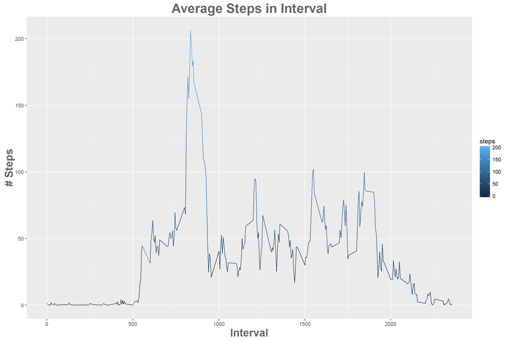

```r
max_value <- ds[which(ds$steps==max(ds$steps, na.rm = TRUE)),]


mean_steps_per_int <- aggregate(steps ~ interval, ds ,mean )
qplot(interval, steps, data=mean_steps_per_int, geom="line") + geom_line(aes(colour = steps))+ ggtitle("Average Steps in Interval") +
  labs(x="Interval",y="# Steps") +   theme(plot.title = element_text(family = "Arial", color="#666666", face="bold", size=22)) +  theme(axis.title = element_text(family = "Trebuchet MS", color="#666666", face="bold", size=18))
```

```r
print(paste("The 5 min interval with max no of steps is :", ds[which(ds$steps==max(ds$steps, na.rm = TRUE)),3]))
```

[output not shown]

#### 6. Code to describe and show a strategy for imputing missing data

```r
print(paste("Total no of rows of missing data are :",sum(is.na(ds$steps))))
```

```
## [1] "Total no of rows of missing data are : 2304"
```

Imputation Strategy : Missing values are imputed as follows : For those steps that have NA value select their interval and find the mean of all steps that fall in that interval.

```r
ds_imputed <- transform(ds, steps = ifelse(is.na(ds[,1]), mean_steps_per_int$steps[match(ds$interval,mean_steps_per_int$interval)], ds$steps ))
imputed_day <-  aggregate(data = ds_imputed, steps ~ date, sum)
mean_imp = mean(imputed_day$steps)
print(paste("Mean of steps taken each day (after imputation)",mean_imp));
```

```
## [1] "Mean of steps taken each day (after imputation) 10766.1886792453"
```

```r
median_imp = median(imputed_day$steps)
print(paste("Mean of steps taken each day (after imputation)",median_imp));
```

```
## [1] "Mean of steps taken each day (after imputation) 10766.1886792453"
```

#### 7. Histogram of the total number of steps taken each day after missing values are imputed

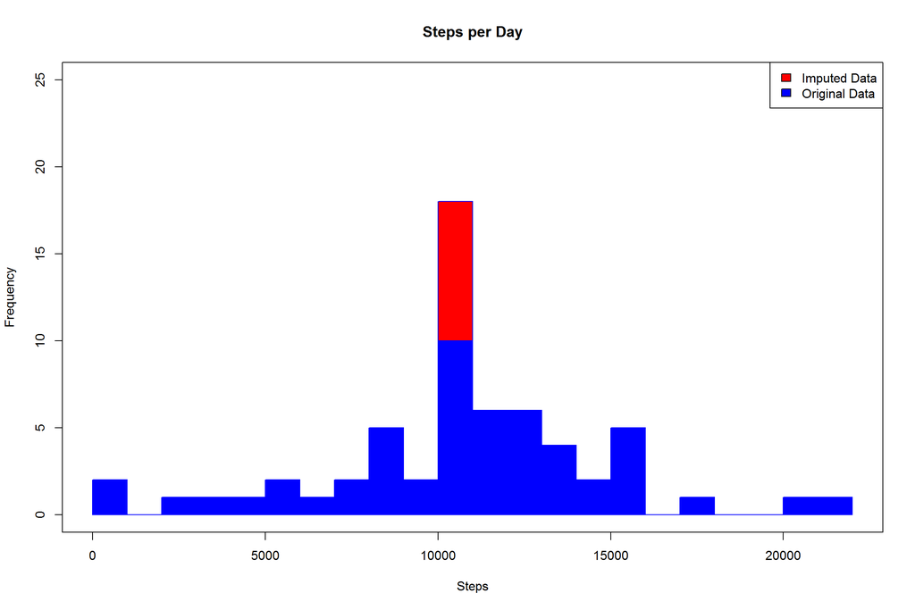

```r
hist(imputed_day$steps,  breaks = 20, col="red", ylim = c(0,25),  main="Steps per Day", xlab="Steps", border="blue")
hist(ds_day$steps,  breaks = 20, col="blue",  main="Steps per Day", xlab="Steps", border="blue", add=T)


box()
legend("topright", c("Imputed Data", "Original Data"), fill=c("red", "blue") )
```

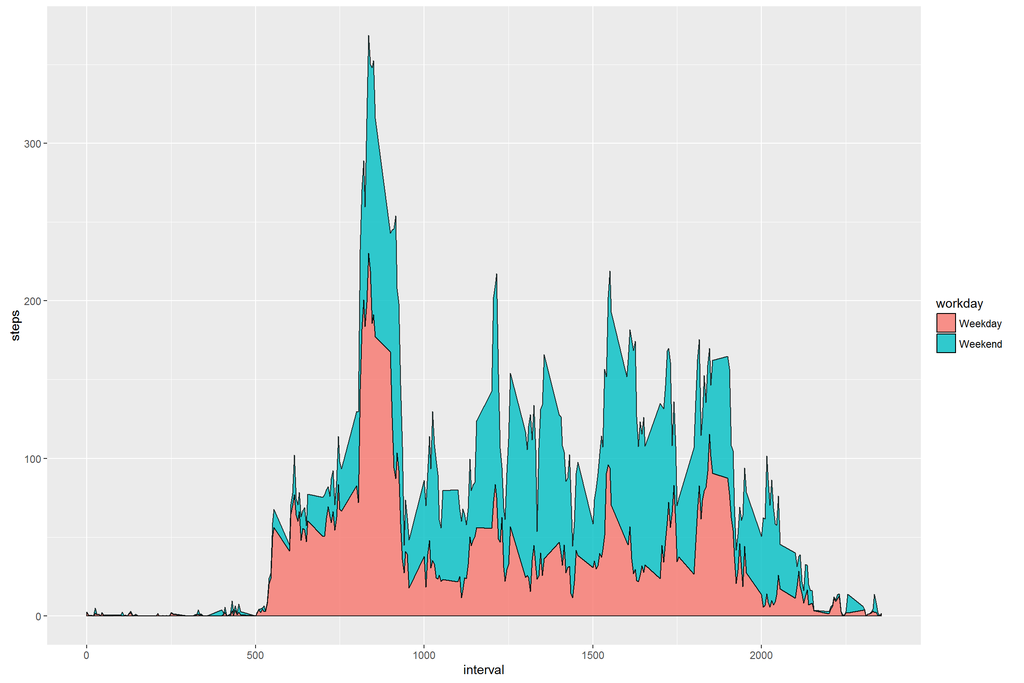

```r
ds_imputed$day = weekdays(ds_imputed$date)
ds_imputed$day = weekdays(ds_imputed$date)
ds_imputed$workday = ifelse(ds_imputed$day %in% c("Saturday" , "Sunday"), "Weekend" , "Weekday")
mean_steps_weekday <- aggregate(steps ~ interval + workday , ds_imputed, mean )
ggplot(mean_steps_weekday, aes(x=interval, y=steps, group = workday, color= workday, fill=workday))+   geom_area(colour="black",  alpha=.8)
```